# The Language of dplyr and ggplot

Kate Nelson

1/31/2022

# Objectives

- Get familiar with `dplyr` notation
- Use `dplyr` to subset and order data
- Know how to use `dplyr` to aggregate data and create new variables
- Get familiar with `ggplot2` notation
- Know how to create basic plots using `ggplot2`

# Notation to know

`tidyverse` packages are intended to make data science more intuitive. As much as possible they use a format that is intended to be *“readable”*. Key *punctuation* that makes this happen include:

- `%>%` for data manipulation using `dplyr`
  - This is a **pipe** that sends data from one operation on the left to another operation on the right.
- `+` for graphic construction using `ggplot2`
  - This is used to add different layers (points and lines) and components (title, axis labels, etc…) to plots and maps.
- Writing good readable code using `dplyr` means we usually start by specifying the subject of the code that we are operating on, then specify the actions that are to be performed on the subject.
  - E.g. `awesome_data %>% do_something() %>% print()`

# `dplyr` functions to know

There are a lot of functions (or “*verbs*”) in `dplyr`. The most commonly used are:

- `select()`
- `filter()`
- `arrange()`
- `mutate()`
- `summarize()`
- `group_by()`

There are also variations on these functions such as `mutate_if` or `summarize_all` that allow you to specify conditions on which to apply these functions.

# Subsetting

- To subset dataframes using `dplyr` use `select()` to choose columns or `filter()` to choose rows.

```r
data("ChickWeight")
  head(ChickWeight)
```

```
##   weight Time Chick Diet
## 1     42    0     1    1
## 2     51    2     1    1
## 3     59    4     1    1
## 4     64    6     1    1
## 5     76    8     1    1
## 6     93   10     1    1
```

```r
ChickWeight %>%
  select(weight, Time, Diet) %>%
  filter(Diet == 2) %>%
  head()
```

```
##   weight Time Diet
## 1     40    0    2
## 2     50    2    2
## 3     62    4    2
## 4     86    6    2
## 5    125    8    2
## 6    163   10    2
```

# About `select()`

- Note that `select()` will take a simple comma separated list of column names as input.
  - Because we have *piped in* the original dataset we don’t need to specify the name of the dataset.
  - You can explicitly specify that you want `dplyr` to use the piped in dataset using `.` as in: `ChickWeight %>% select(., weight, Time, Diet) %>% filter(., Diet == 2)`

```r
ChickWeight %>%
  select(., weight, Time, Diet) %>%
  filter(., Diet == 2) %>%
  head()
```

```
##   weight Time Diet
## 1     40    0    2
## 2     50    2    2
## 3     62    4    2
## 4     86    6    2
## 5    125    8    2
## 6    163   10    2
```

- You can use `:` in `select()` to return a range of columns as in: `ChickWeight %>% select(weight:Time)`
- You can also use `c()` in `select()` to return a custom list of variables

There are lots of options for `select()` that you can check out using `?select()`. Or see the [online reference materials](https://dplyr.tidyverse.org/reference/select.html).

```r
ChickWeight %>%
  select(., weight:Diet) %>%
  filter(., Diet == 2) %>%
  head()
```

```
##   weight Time Chick Diet
## 1     40    0    21    2
## 2     50    2    21    2
## 3     62    4    21    2
## 4     86    6    21    2
## 5    125    8    21    2
## 6    163   10    21    2
```

# Ordering using `arrange()`

We can use `arrange()` much like we used the *base R* function `order()`.

- `arrange()` simply arranges a dataframe in ascending order by a provided variable/s
  - If multiple variables are provided it sorts first by the first variable provided, then while maintaining the order of the first variable sorts by the second variables, and so forth and so on.

```r
ChickWeight %>%
  arrange(., weight) %>%
  head(10)
```

```
##    weight Time Chick Diet
## 1      35    2    18    1
## 2      39    2     3    1
## 3      39    0    18    1
## 4      39    0    27    2
## 5      39    0    28    2
## 6      39    0    29    2
## 7      39    0    33    3
## 8      39    0    36    3
## 9      39    0    48    4
## 10     40    0     2    1
```

- to get descending order use the function `desc()` inside `arrange()`

# Create new variables with `mutate()`

`mutate()` is a lovely function for creating new variables and adding them to an existing dataset.

- To use `mutate()` you specify a new column/variable name and then set it equal to something.
  - You can create multiple columns at one time by separating new column specifications with a `,`.
  - If you use an existing column name you will overwrite it.
  - You can use functions within `mutate()` to create the values of the new column.

```r
ChickWeight %>%
  mutate(Chick_name = as.character(Chick),
         weight = weight * 0.0022, #convert from grams to pounds
         diet_time = paste0(Diet, "_", Time)) %>% #create a unique diet-time identifier
  head()
```

```
##   weight Time Chick Diet Chick_name diet_time
## 1 0.0924    0     1    1          1       1_0
## 2 0.1122    2     1    1          1       1_2
## 3 0.1298    4     1    1          1       1_4
## 4 0.1408    6     1    1          1       1_6
## 5 0.1672    8     1    1          1       1_8
## 6 0.2046   10     1    1          1      1_10
```

# Summarize your data

The `summarize()` function in `dplyr()` does much the same thing as the `aggregate()` function in *base R*.

- Like `mutate()` in `summarize()` you specify a new column name and an operation that produces the values in that column.
  - Unlike `mutate()` you do not add onto your existing dataset, but create an entirely new one.
  - `summarize()` will aggregate data within columns of your dataframe.
  - You can create multiple new summary columns at one time.

```r
ChickWeight %>%
  summarize(count_chicks = n_distinct(Chick),
            average_wt = mean(weight),
            last_time = last(Time))
```

```
##   count_chicks average_wt last_time
## 1           50   121.8183        21
```

# Grouping!

What if we want to create summary information for groups within our dataframe? Or arrange data within groups? Or apply a `mutate()` function within groups?

- `group_by()` will group your dataframe by values in a provided column/s so that following operations are performed **within** groups.
- Simply enter a column name/s in the `group_by()` function.
- The final output should include the variable used for grouping in the dataframe.

```r
ChickWeight %>%
  group_by(Diet) %>%
  summarize(count_chicks = n_distinct(Chick),
            average_wt = mean(weight)) %>%
  arrange(average_wt)
```

```
## # A tibble: 4 x 3
##   Diet  count_chicks average_wt
##   <fct>        <int>      <dbl>
## 1 1               20       103.
## 2 2               10       123.
## 3 4               10       135.
## 4 3               10       143.
```

# `ggplot2` functions to know

There are also a lot of functions in `ggplot2`. The most basic function of all is `ggplot()`, which simply creates a plot environment. Many `ggplot2` functions specify different types of plots using what are called `geoms`. Common `geoms` include:

- `geom_point()`
- `geom_smooth()`
- `geom_histogram()`
- `geom_boxplot()`
- `geom_bar()`

There are also other functions that customize your plot appearance. Such as:

- `theme()`
- `labs()`
- `scale_colour_brewer()`

# Basic plots

- Building a plot is like making a layer cake. We start with the base (the cake), then add `geoms` (the layers) and aesthetic options (the frosting), then add customization (the sprinkles). Each part of the plot is separated by a `+`.
- Different `geoms` require different types and numbers of variables. These are specified within a `geom` function using what are called aesthetic mappings `aes()`.
  - The arguments in `aes()` tell `ggplot` what variables belong where on your plot. (E.g. Put time on the x axis.)
    - `aes()` is where you provide information about things that should be treated differently by `ggplot`
    - Outside the `aes()` function, but with your `geom` function you can specify things like line color (`color`) or point fill color (`fill`) or point size (`size`) or transparency (`alpha`) that apply to **ALL** data elements in the plot.

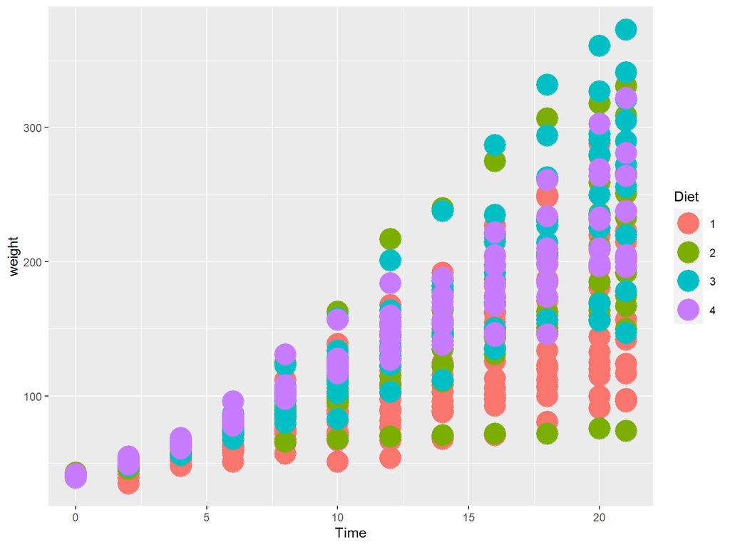

```r
ggplot(ChickWeight) +
  geom_point(aes(x = Time, y = weight, color=Diet), size = 8)
```

The `geom_smooth()` function creates a smoothed line using a *loess* smoothing algorithm by default (if you have less than 1,000 points) that essentially takes a local average of your points.

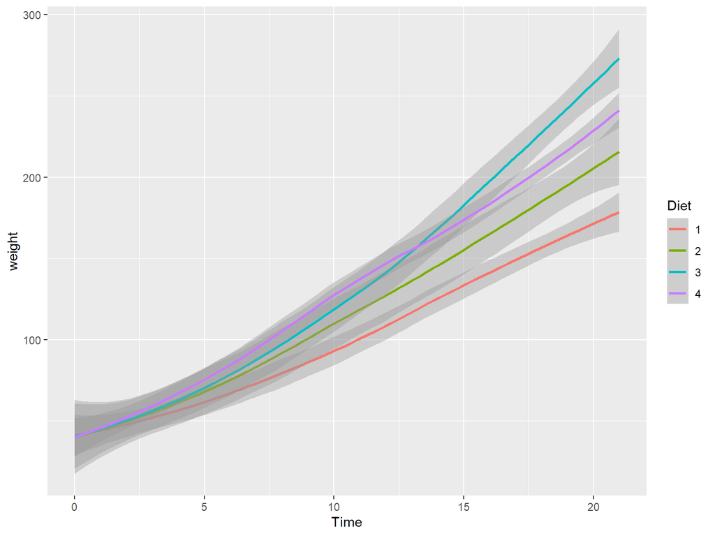

```r
ggplot(ChickWeight) +
  geom_smooth(aes(x = Time, y = weight, color = Diet), size = 1)
```

These plots are nice for simple investigation of trends.

# Histograms and boxplots

We can use histograms and boxplots to examine the distribution of a variable.

- `geom_histogram()`only uses a single specified dimension in the `aes()`
- `geom_boxplot()` can use multiple dimensions in `aes()` to provide boxplots for a variable that are grouped by another category
- addition of a theme template such as `theme_classic()` changes the appearance of the plot layout
- `labs()` and `xlab()` and `ylab()` can be used to pretty up the axis labels and title

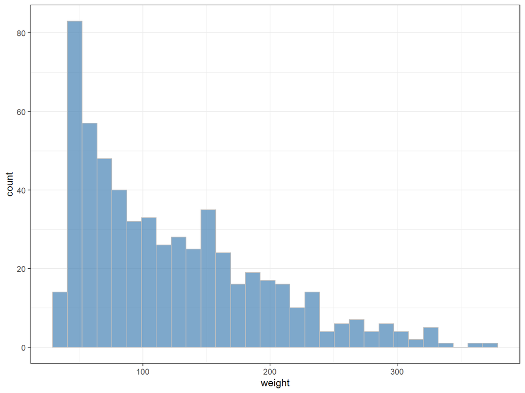

```r
ggplot(ChickWeight) +
  geom_histogram(aes(x = weight), fill = "steelblue", color = "gray", alpha = 0.7) +
  theme_bw()
```

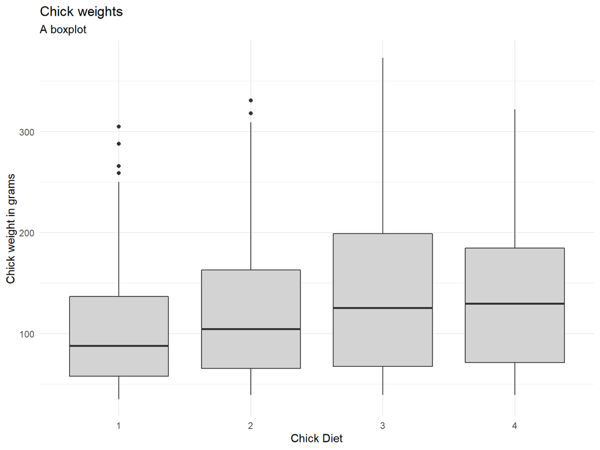

```r
ggplot(ChickWeight) +
  geom_boxplot(aes(y = weight, x= Diet), fill = "lightgray") +
  theme_minimal() +
  labs(title = "Chick weights", subtitle = "A boxplot") +
  xlab ("Chick Diet") +
  ylab ("Chick weight in grams")
```

# Barchart

- Use `geom_bar()` to create a bar chart giving counts or percentages of each value for a single dimension.
- Use `geom_col()` to create a bar chart giving counts or percentages of values for groups in your data.
- Use `scale_fill_brewer()` to use a color scale from [ColorBrewer](https://colorbrewer2.org/#type=sequential&scheme=BuGn&n=3).
- Use `theme(axis.text.x )` options to change the size, rotation, and font type of axis text (in this case for the x axis)

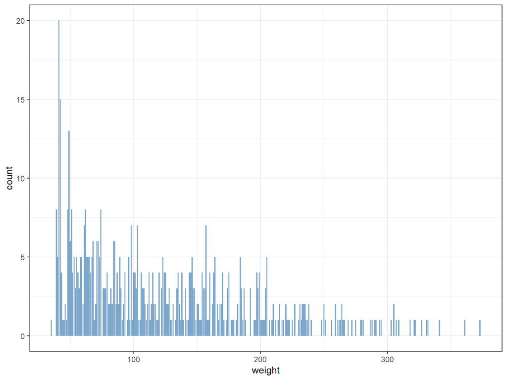

```r
ggplot(ChickWeight) +
  geom_bar(aes(x = weight), fill = "steelblue",  alpha = 0.7) +
  theme_bw()
```

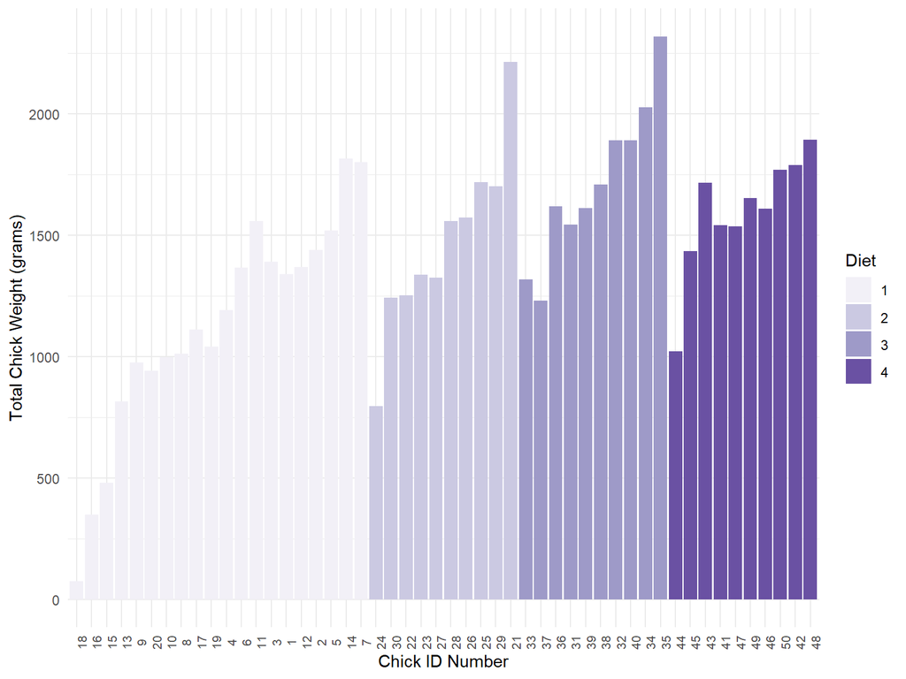

```r
ggplot(ChickWeight) +
  geom_col(aes(x = Chick, y = weight, fill = Diet)) +
  theme_minimal() +
  scale_fill_brewer(palette = "Purples") +
  xlab("Chick ID Number") +
  ylab("Total Chick Weight (grams)") +
  theme(axis.text.x = element_text(angle = 90, size = 8))
```